# Handout – Working with Geo-Data

## Scales

Each visual property that a variable maps to, belongs to a scale that you can further adjust. For example, you might apply a log-transformation to the x- and/or y-axis. Or you can also change the color palette that is used for the color of points in a scatterplot. If a scale uses a legend, you can adjust its appearance, change the title or its position, among other things:

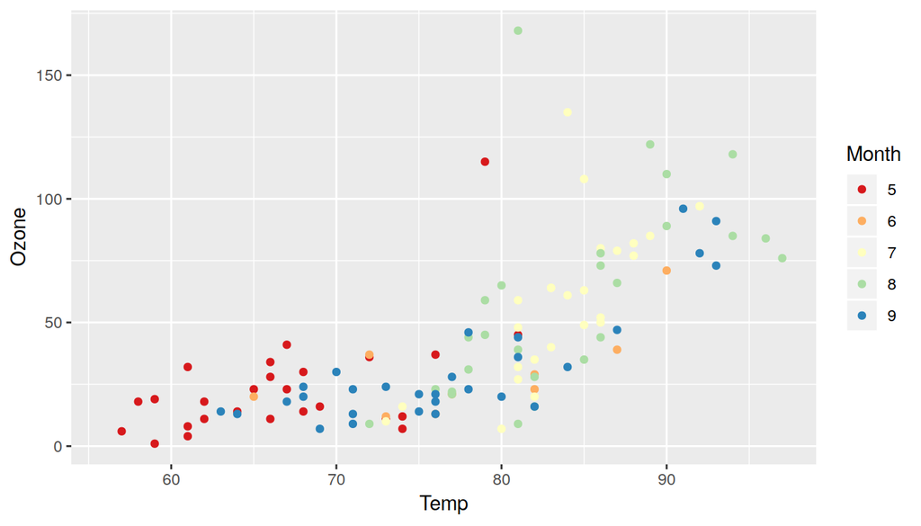

```r
ggplot(airquality) +
    geom_point(aes(x = Temp, y = Ozone,
                   color = as.ordered(Month))) +
    scale_color_brewer(palette = 'Spectral',
                       guide = guide_legend(title = 'Month'))
```

## Facets

*Facets* allow you to create small multiples of your plots. Instead of projecting all data points into a single plot, split them into groups depending on a variable and then create a small plot for each group. You can use `facet_wrap()` to do this and specify the variable for splitting as “R formula”, e.g. `~ X` where `X` is the variable to split by:

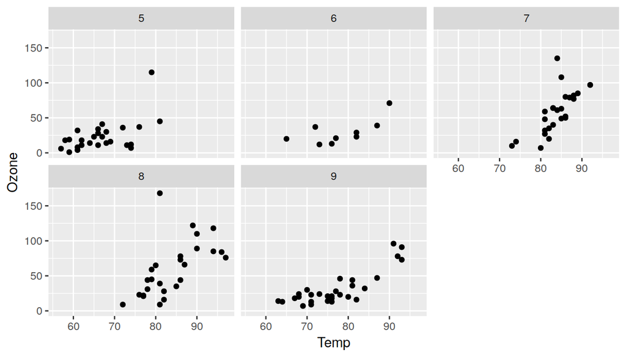

```r
# make a plot for each month. convert to ordered factor before
ggplot(airquality) +
    geom_point(aes(x = Temp, y = Ozone)) +
    facet_wrap(~ as.ordered(Month))
```

You can specify more options in `facet_wrap()`, e.g. restrict the number of rows or columns.

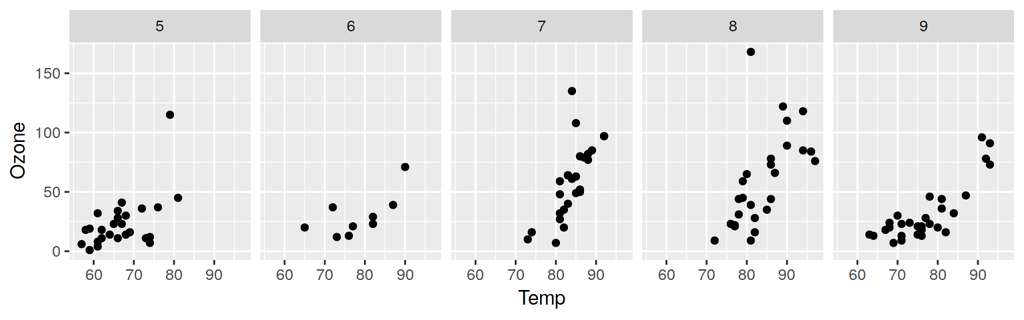

```r
ggplot(airquality) +
    geom_point(aes(x = Temp, y = Ozone)) +
    facet_wrap(~ as.ordered(Month), nrow = 1)
```

By default, all plots share the same scales on the axes which ensures better comparability. However, you can change that using the `scales` argument.

## Themes

*Themes* control the overall appearance of a plot. There are several predefined themes which define a “plot style”. They are all prefixed by `theme_`.

For example, `theme_bw()` which is optimized for black and white prints:

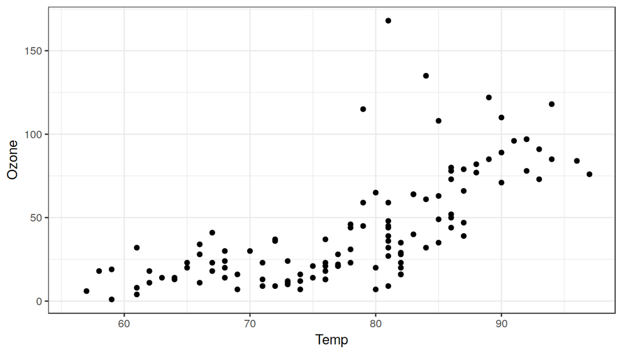

```r
ggplot(airquality, aes(x = Temp, y = Ozone)) + geom_point() +
    theme_bw()
```

For geo-spatial plots, you can often remove the axis labels and ticks, which can be done like this:

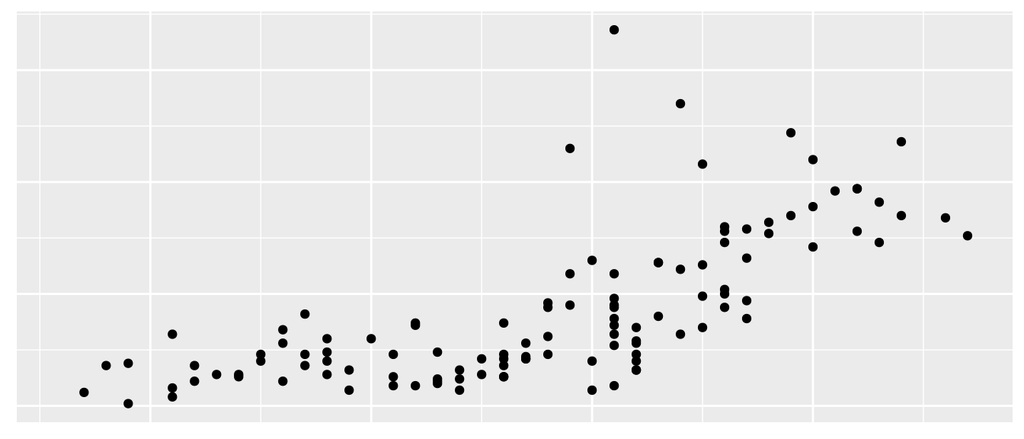

```r
ggplot(airquality, aes(x = Temp, y = Ozone)) + geom_point() +
    theme(axis.title = element_blank(),
          axis.ticks = element_blank(),
          axis.text = element_blank())
```

An alternative is `theme_void()`, which removes all elements around the actual plot.

## Plots as objects

A ggplot object can be assigned a name just as any other object in R:

```r
myplot <- ggplot(airquality, aes(x = Temp, y = Ozone))
myplot   # shows an "empty" plot
```

You can re-use the ggplot object and try out different layers or themes:

```r
myplot + geom_point()
```

```r
myplot + geom_point(position = position_jitter()) +
    theme_minimal()
```

You can eventually save the plot to disk with `ggsave()`:

```r
final_plot <- myplot + geom_point(position = position_jitter())
ggsave('example_saved_figure.png',
       plot = final_plot,
       width = 4,
       height = 3)
```

There are several options to configure the output file (see `?ggsave`):

- plot dimensions (by default in inch)
- plot resolution
- format (PNG, PDF, etc.) – determined by file extension

## Common mistakes

A very common mistake is to accidentally put `+` on a new line:

```r
ggplot(airquality, aes(x = Temp, y = Ozone))
  + geom_point()
```

`Error: Cannot use "+.gg()" with a single argument. Did you accidentally put + on a new line?`

The `+` operator must appear before the line break (the same is true for other operators like `%>%` used in *dplyr*):

```r
ggplot(airquality, aes(x = Temp, y = Ozone)) +
  geom_point()
```

The type of your variables determines its scale for plotting. E.g. here you might want to use a discrete scale:

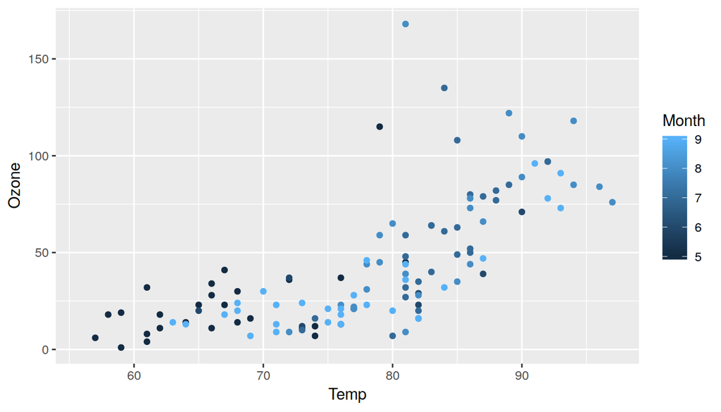

```r
ggplot(airquality, aes(x = Temp, y = Ozone, color = Month)) +
  geom_point()
```

Converting the numerical to a factor tells ggplot that a discrete scale is appropriate:

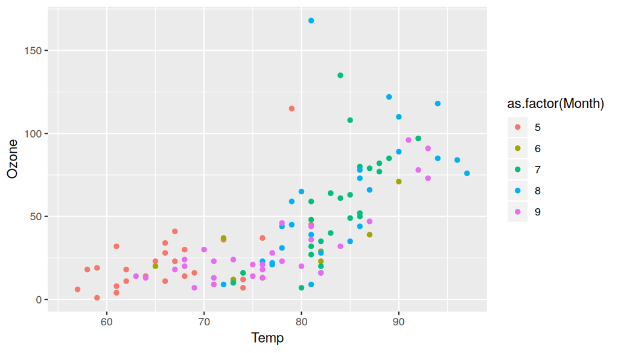

```r
ggplot(airquality, aes(x = Temp, y = Ozone,
                       color = as.factor(Month))) +
  geom_point()
```

# Data linkage with *dplyr*

## Left and right (outer) joins

*Left and right outer joins* keep all observations on the left-hand or right-hand side data sets respectively. Unmatched rows are filled up with *NA*s:

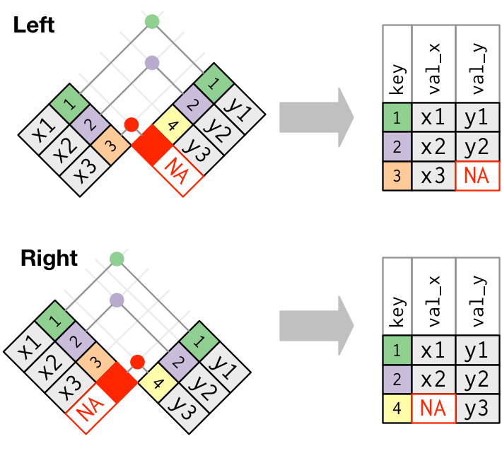

Left and right join. Source: Grolemund, Wickham 2017: R for Data Science

## Inner joins

Syntax: `inner_join(a, b, by = <criterion>)`

## Specifying matching criteria

Parameter `by` can be:

1. a character string specifying the key for both sides, e.g.: `inner_join(pm, city_coords, by = 'city')` will match `city` column in `pm` with `city` column in `city_coords`;
2. a vector of character strings specifying several keys to match both sides, e.g.: `inner_join(pm, city_coords, by = c('city', 'country')` will match those rows, where `city` *and* `country` columns match;
3. a *named* character string vector like `inner_join(pm, city_coords, by = c('cityname' = 'id')`, which will match the column `cityname` in `pm` with the column `id` in `city_coords`

# Specific hints / further information for excercises

## Exercise 2

### Finding out geo-coordinates

We will later learn how to use the Google Maps API to geocode (i.e. get the geo-coordinates) places programmatically. For the purpose of this excerise, it’s enough to do it manually.

There are several websites that offer free manual geocoding, e.g.:

- https://google-developers.appspot.com/maps/documentation/utils/geocoder/
- https://www.mapdevelopers.com/geocode_tool.php

Both work the same way: You enter a request (i.e. an address, city name, restaurant name, etc.) and it spits out the result, including the longitude and latitude. **Please be aware that the first service returns the geo-coordinate with latitude first, followed by longitude (“Location: …”).**

### Constructing a dataset quickly from within R

You can construct the small dataset directly within R by passing place labels, longitude and latitudes as separate column vectors:

```r
places <- data.frame(
    label = c('born', 'living', 'neven been there'),
    lng = c(  12.590, 13.402,   8.0456),
    lat = c(  51.279, 52.520,   52.276)
)
```

### Loading the worldmap dataset

The following loads the world map dataset from the `maps` package as *Simple Features* spatial dataset:

```r
library(maps)
library(sf)

worldmap_data <- st_as_sf(map('world', plot = FALSE,
                              fill = TRUE))
```

### Filtering the worldmap dataset

You can filter the worldmap data from the `maps` package by using the “ID” column:

```r
sweden <- worldmap_data[worldmap_data$ID == 'Sweden',]
```

Using the `%in%` operator when selecting several countries:

```r
sel_cntrs <- c('Sweden', 'Denmark', 'Finland', 'Norway', 'Iceland')
scandinavia <- worldmap_data[worldmap_data$ID %in% sel_cntrs,]
```

### Restricting the display window

You can specify a “display window” (i.e. “zooming in” to a certain region) by setting a limit on the displayed longitude range (`xlim`) and latitude range (`ylim`) in the `coord_sf()` function:

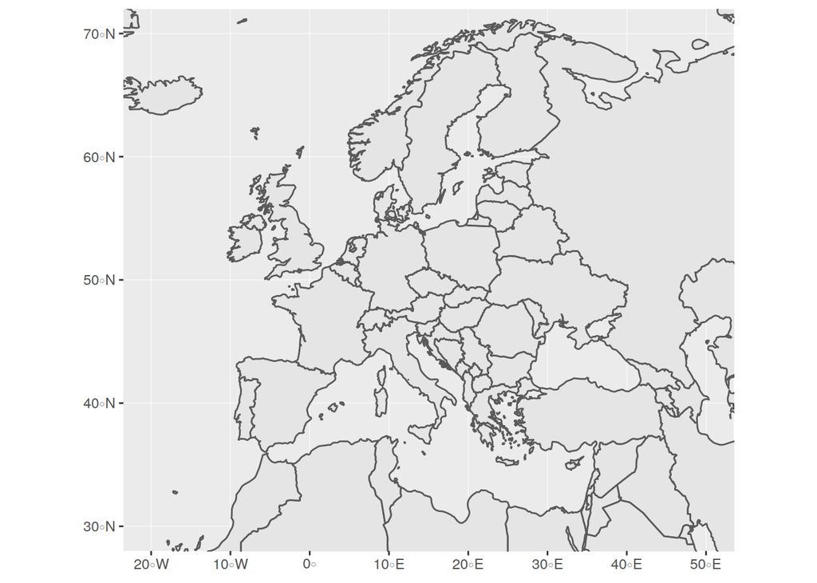

```r
ggplot() + geom_sf(data = worldmap_data) +
    coord_sf(xlim = c(-20, 50), ylim = c(30, 70))
```

We will learn more options on how to specify display windows in the second part of the workshop.

## Exercise 3

### Loading and filtering the worldmap dataset

See hints in exercise 2.

### Grouping and counting

You can use the function `group_by()` from the package `dplyr` to group the dataset and then pass the groups to the function `count()` to count observations in each group. For example, if you want to group the dataset `msleep` by variable `vore` and count the observations in each group, you can do so as follows:

```r
library(dplyr)
library(ggplot2)  # for the "msleep" example dataset

group_by(msleep, vore) %>% count()
```

```
## # A tibble: 5 x 2
## # Groups:   vore [5]
##   vore        n
##   <chr>   <int>
## 1 <NA>        7
## 2 carni      19
## 3 herbi      32
## 4 insecti     5
## 5 omni       20
```

You can also group by several variables, for example by each combination of the variables `vore` and `order` that exist in the dataset:

```r
# 1. group and count by variables "vore" and "order"
# 2. ungroup and show only a sample of 5 rows
group_by(msleep, vore, order) %>% count() %>%
    ungroup() %>% sample_n(5)
```

```
## # A tibble: 5 x 3
##   vore  order               n
##   <chr> <chr>           <int>
## 1 herbi Artiodactyla        5
## 2 herbi Pilosa              1
## 3 herbi Perissodactyla      3
## 4 <NA>  Soricomorpha        1
## 5 omni  Didelphimorphia     1
```

For the given task, you must group the observations by city **and** city longitude/latitude.

### Restricting the display window

See hints in exercise 2.

## Exercise 4

When loading the `bln_plr_sozind_data.csv` dataset, make sure that the variable `SCHLUESSEL` is loaded as character string, **not** as integer (use `colClasses = c('SCHLUESSEL' = 'character')` in `read.csv()`).

After loading the spatial dataset `bln_plr.geojson` make sure to set the CRS: `st_crs(<DATASET>) <- 25833`.

More information on the `bln_plr_sozind_data.csv` dataset:

- source: Berlin Senate Dept. for Urban Dev. and Housing, *Monitoring Soziale Stadtentwicklung 2017* via [FIS-Broker](https://fbinter.stadt-berlin.de/fb/index.jsp)
- variables:
  - `STATUS1`: Unemployment rate 2016 in percent
  - `STATUS2`: Long term unemployment rate 2016 in percent
  - `STATUS3`: Pct. of households that obtain social support (“Hartz IV”) 2016
  - `STATUS4`: Portion of children under 15 living in household that obtains social support (“Hartz IV”) 2016
  - `DYNAMO1` to `4`: Change in the above indicators from the previous year

## Exercise 5

After loading the spatial dataset `nutsrg_2_2016_epsg3857_20M.json` make sure to set the CRS: `st_crs(<DATASET>) <- 3857`.

More information on the `tgs00010_unempl_nuts2.csv` dataset:

- source: [Eurostats / Regions & cities](https://ec.europa.eu/eurostat/web/regions/data/main-tables)
- variables:
  - `sex`: `F` means unemployment rate for women, `M` for men, `T` for both
  - `nuts`: NUTS level-2 region code
  - `year`: year when the data was collected
  - `unempl_pct`: unemployment rate in percent

In case you want to use a different Eurostats dataset or a different NUTS map, you can download these resources here:

- for the datasets: https://ec.europa.eu/eurostat/data/browse-statistics-by-theme
- for the NUTS maps: https://github.com/eurostat/Nuts2json

# Sources for geo-data

## R packages

The following packages come directly with geo-data or provide means to download them programmatically:

- [maps](https://cran.r-project.org/web/packages/maps/index.html): World, USA, US states, US counties and more
- [mapdata](https://cran.r-project.org/web/packages/mapdata/index.html): World in higher resolution, China, Japan and more
- [rnaturalearth](https://cran.r-project.org/web/packages/rnaturalearth/index.html): *R package to hold and facilitate interaction with natural earth vector map data.* → see next section
- [OpenStreetMap](https://cran.r-project.org/web/packages/OpenStreetMap/): Access to the OpenStreetMap API → see next section

## Natural Earth Data

[naturalearthdata.com](http://www.naturalearthdata.com/): *Natural Earth is a **public domain map dataset** available at 1:10m, 1:50m, and 1:110 million scales. Featuring tightly integrated vector and raster data, with Natural Earth you can make a variety of visually pleasing, well-crafted maps with cartography or GIS software.*

Provides vector data for:

- countries and provinces, departments, states, etc.
- populated places (capitals, major cities and towns)
- physical features such as lakes, rivers, etc.

You can either download the data directly from the website or use the package [rnaturalearth](https://cran.r-project.org/web/packages/rnaturalearth/index.html).

## Open Street Map

- provides even more detail than *Natural Earth Data*: streets, pathways, bus stops, metro lines, etc.
- [GeoFabrik](https://download.geofabrik.de/) provides downloads of the raw data
- is much harder to work with b/c of the complexity of the data

[OSM Admin Boundaries Map](https://wambachers-osm.website/boundaries/): web-service to download administrative boundaries worldwide for different levels in different formats (shapefile, GeoJSON, etc.); contains meta-data (depending on country) such as AGS in Germany

[This wiki article](https://wiki.openstreetmap.org/wiki/DE:Grenze#Gemeinden_.E2.80.93_admin_level.3D7.E2.80.938) explains which OpenStreetMap administrative boundary levels correspond to which regional level in Germany (e.g. level 6 corresponds to “Kreise”).

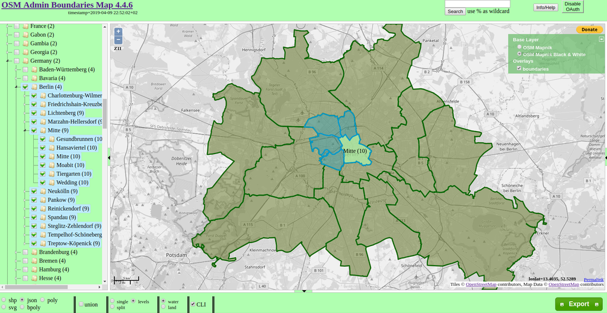

OSM Admin Boundaries screenshot

## Administrative authorities in the EU

Administrative authorities often provide geo-data. In the EU, the main source is [Eurostat](https://ec.europa.eu/eurostat) which provides data referenced by NUTS code.

- [main NUTS datasets as SHP, GeoJSON, TopoJSON, SVG](https://ec.europa.eu/eurostat/web/gisco/geodata/reference-data/administrative-units-statistical-units/nuts)
- Nuts2json provides another overview for GeoJSON and TopoJSON datasets
- [correspondence tables](https://ec.europa.eu/eurostat/web/nuts/correspondence-tables/postcodes-and-nuts) map national structures and postcodes to NUTS regions

## Administrative authorities in Germany

*Statistisches Bundesamt* provides [geo-referenced data](https://www.destatis.de/DE/Themen/Laender-Regionen/Regionales/_inhalt.html), such as:

- [Gemeindeverzeichnis](https://www.destatis.de/DE/Themen/Laender-Regionen/Regionales/Gemeindeverzeichnis/_inhalt.html): AGS, area, population, etc.
- [Regionaldatenbank](https://www.regionalstatistik.de/genesis/online): GDP, building land value, etc.
- [govdata.de](https://www.govdata.de/): Open data portal for Germany – lots of data, but not very well curated and documented

Berlin:

- [Senate Department for Urban Development and Housing](http://www.stadtentwicklung.berlin.de/planen/basisdaten_stadtentwicklung/index.shtml) for example provides datasets based on [LOR units](http://www.stadtentwicklung.berlin.de/planen/basisdaten_stadtentwicklung/lor/index.shtml)
- [FIS Broker](https://fbinter.stadt-berlin.de/fb/index.jsp) is a web-service providing all publicly available geo-referenced data – [this post](https://lab.technologiestiftung-berlin.de/projects/fisbroker-to-qgis/index.html) shows how to use it

## What about historical data?

Geographic areas such as administrative borders change. Identifiers may change, too. Make sure to use the version that matches your dataset!

- *Eurostat* provides historical NUTS areas back to 2003
- *Statistisches Bundesamt* also provides an archive

# Glossary

**AGS:** *Amtlicher Gemeindeschlüssel* – municipality identificator in Germany.

**CRS:** Coordinate reference system – defines the coordinate system (spherical, ellipsoid, cartesian, etc.), unit of measurment (degrees, meters, etc.) and map projection of points in a spatial dataset in order to locate geographical entities

**CRAN:** *Comprehensive R Archive Network* – repository of packages that extend the statistical software suite R.

**EPSG:** *European Petroleum Survey Group* – a scientific organization tied to European petroleum industry. Created the *EPSG Geodetic Parameter Set*, which among other things contains a database of →CRS identified by EPSG →SRID code

**ETRS89:** *European Terrestrial Reference System 1989* – EU-recommended frame of reference for geodata for Europe; defines a →CRS.

**GIS:** *Geographic information system* – a system such as a software like →QGIS designed to work with geographic data.

**Lat / Latitude:** Geographic coordinate that defines the north-south position of a point on Earth as an angle between -90° (south pole) and 90° (north pole). The equator is located at 0° latitude.

**Lon / Long / Lng / Longitude:** Geographic coordinate that defines the east-west position of a point on Earth as an angle between -180° (westward) and 180° (eastward). The Prime Meridian is located at 0° longitude.

**LOR:** *Lebensweltlich orientierte Räume* – structures the city area of Berlin into sub-regions at three different levels; each area is identified by a LOR code.

**NUTS:** *Nomenclature of Territorial Units for Statistics* – divides the EU territory into regions at 3 different levels for socio-economic analyses of the regions; each area is identified by a NUTS code.

**QGIS:** free and open-source →GIS application.

**SRID:** *Spatial Reference System Identifier* – identifies a →CRS by a unique code number which is listed in the →EPSG database. Because of this, it is often also called EPSG code or number. Examples: EPSG:4326 refers to →WGS84; EPSG:4258 refers to →ETRS89.

**SRS:** *Spatial Reference System* – see →CRS.